# Market Analysis : Cyclistic Bike share program

R Amarthya Sreechand

2025-06-29

## Personal Objective :

- **This project was undertook to impart a systematic mindset for solving complex problems, and thus is the beginning of my learning journey in building and refining a system on top of the Google data analysis process for solving complex problems.**
- The following is a system for analyzing data which anyone can apply to real world analyses. To put this system out into the world, and for myself to refer in my upcoming projects, I used the data of a bike sharing company called ‘Cyclistic’ (Divvy ).

## MARKET ANALYSIS : Cyclistic Bike Share Program

- You can skip to the final slideshow report section for the Summary of the Analysis. Or, you can view it here :👉[Click Here to view the Final Slideshow Report](https://docs.google.com/presentation/d/1t4PNAyT26frdq2fmbp1TTmcjhgb-E8NzZtqUuh3D1JU/edit?usp=sharing)
- Check the Changelog here :👉[Click here to view the Changelog](https://docs.google.com/document/d/18zyK9TFA0BY8_LiS-mG935c3jkJ4hr1F7vXocNGYBWg/edit?usp=sharing)

## CONTEXT :

Cyclistic is a bike-share program that features more than 5,800 bicycles and 600 docking stations. Cyclistic users are more likely to ride for leisure, but about 30% use the bikes to commute to work each day. Cyclistic’s marketing strategy relied on building general awareness and appealing to broad consumer segments. One approach that helped make these things possible was the flexibility of its pricing plans: single-ride passes, full-day passes, and annual memberships.

- Customers who purchase single-ride or full-day passes are referred to as casual riders.
- Customers who purchase annual memberships are Cyclistic members.

Cyclistic’s finance analysts have concluded that annual members are much more profitable than casual riders. Although the pricing flexibility helps Cyclistic attract more customers, maximizing the number of annual members will be key to future growth.

Therefore, Cyclistic marketing team has set a clear goal :

- **Design marketing strategies aimed at converting casual riders into annual members.**

### Factorization Method:

For achieving this goal, I need to understand how (Categories) Annual members & Casual riders differ in their behavioral patterns or trends.

I will be using the Factorization method for analyzing the data. Where, Quantitative data is classified into Environmental and Engagement factors. Then, the **Data patterns or trends are discovered by combining Environmental factor/s with Engagement factors.**

**Qualitative data -**

**Environmental/Contextual factors (Categories):**

- Time (Eg; Weekday, Month, …)
- Location/Geography (Eg; Bike Stations, Routes, City, …)
- User Types (Eg; Member/Casual, User/Customer/Lead, …)
- Traffic
- Weather/Climate
- Human Events (Seasonal/ Recurring fests, …)
- …

**Quantitative data -**

**Engagement factors (Measurable):**

- Values (Eg; Trip duration, Trip frequency, …)

Actionable insights developed from the data insights (trends/patterns) are implemented on the the individual or on the combination of Contextual factors (Categories). So I would have to keep them in the back of my mind for asking the right questions.

## 1. ASK PHASE (Deliverable = Business Task)

This is the MOST IMPORTANT Phase of the Data analysis process. If you got this wrong, then the error would get multiplied in the final result ie; the actionable insights you recommend would be heavily misleading.

So I will take my time to think through this, and use a systematic process to ASK the right questions to define the right Business task to solve the problem.

**1. Problem statement** : What are the differences in behavioral patterns between Casual riders and Annual members from which we can produce actionable marketing strategies to convert Casual riders to Annual members.

**2. Questions** (Used Factorization method to extract the Right Questions) :

Right questions are SMART questions (Specific, Measurable, Actionable, Relevant, and Time bound). Right questions are asked to prepare a Business task and the Scope of Work.

As my investigation is into the difference between Casual riders and Annual members, all of my questions would include Member/Casual User Types (Contextual Factor) as the CORE FACTOR.

1. **Time :**
- What is the average trip duration/ ride count/ total trip duration of Casual riders & Annual members for each **month** in the time period 2019-2020 Q1 ?
- What is the average trip duration/ ride count/ total trip duration of Casual riders & Annual members for each **day of the week** in the time period 2019-2020 Q1 ?
2. **Location/Geography :**
- What are the **stations** with highest Ride counts for Casual riders & Annual members respectively from the year 2019 to 2020 Q1 ?
- Which **route/s** (station pairs) have the highest ride counts/ highest Total trip duration/ highest average trip duration with respect to Casual riders and Annual members from the year 2019 to 2020 Q1 ?
3. **User characteristics :**
- Which of the **genders** have the highest Ride counts/ highest Total trip duration/ highest average trip duration with respect to Casual riders and Annual members in the time period 2019-2020 Q1 ?
- Which of the **age groups** have the highest Ride counts/ highest Total trip duration/ highest average trip duration with respect to Casual riders and Annual members in the time period 2019-2020 Q1 ?

Using these questions, let’s create the Scope of Work -

### **Scope of Work :**

**Data Analyst :** R Amarthya Sreechand

**Client :** Cyclistic

**Business task :** Identify daily and monthly patterns in trip duration and frequency among casual riders and annual members, segmented by gender, age, station activity, and route preferences, to develop targeted marketing strategies that convert casual riders into annual members.

**Major Activities :**

- Collect Data which is relevant, original, comprehensive, current & cited
- Organized and Clean the Data
- Analyze the Data & identify customer behavior systematically
- Share the top 3 high leverage recommendations based on analysis
- Final report for easy comprehension of the analysis

**Project Deliverables :**

- A clear statement of the business task.
- A description of all data sources used.
- Documentation of any cleaning or manipulation of data (Changelog).
- A summary of analysis.
- Supporting visualizations and key findings (Final Report).
- Top 3 recommendations based on analysis.

**Project does not include :**

- Any scope outside the existing stations.
- Cost-Benefit analysis

**Major Milestones :**

- Data preparation and processing : 25/05/2025
- Data analysis : 29/05/2025
- Final report with recommendations : 31/05/2025

**Estimated Completion Date :** 31/05/2025

## 2. PREPARE PHASE (Deliverable = Description of all data sources used)

Now, I have to find the datasets which are Reliable, Original, Complete, Current and Cited, that are relevant for solving the Business task.

### Collection of Data :

- Data sources : To collect reliable, original, complete, latest and cited data, I will be downloading the company’s latest data from the [Cyclistic data repository](https://divvy-tripdata.s3.amazonaws.com/index.html).
  - Divvy_Trips_2019_Q1.zip
  - Divvy_Trips_2019_Q2.zip
  - Divvy_Trips_2019_Q3.zip
  - Divvy_Trips_2019_Q4.zip
  - Divvy_Trips_2020_Q1.zip
- Collected & stored Cyclistic’s data for the :
  - Year 2019
  - First Quarter of the year 2020

### Selecting the appropriate tools :

An important Decision - For viewing the data’s organization, and for efficient analysis.

The Tools are selected using these Criteria :

1. Size of the Datasets :
- ‘< 10 MB’ - Use Excel, Google sheets
- ‘> 10 MB’ - Use SQL, R
2. Storage :
- Database - Use SQL (Eg; BigQuery)
- Cloud / Local storage - Use Google sheets, Excel, R.

**The Logical conclusion from this information is to choose R.**

### Exploring the Data :

Now, let’s load up and explore the datasets in R to check their Schema and how it’s organized so as to determine how to clean and process them in the next Phase.

**- Step 1: Load packages**

```r
# Libraries for Cleaning & Analysis

library(tidyverse)
library(skimr)
library(janitor)
library(lubridate)
library(tidytext)

# Libraries for map generation

library("tidygeocoder")
library("leaflet")
library("mapview")
library("webshot")
```

**- Step 2: Import data**

```r
tripsq1_2019_df <- read_csv("Divvy_Trips_2019_Q1.csv")

tripsq2_2019_df <- read_csv("Divvy_Trips_2019_Q2.csv")

tripsq3_2019_df <- read_csv("Divvy_Trips_2019_Q3.csv")

tripsq4_2019_df <- read_csv("Divvy_Trips_2019_Q4.csv")

tripsq1_2020_df <- read_csv("Divvy_Trips_2020_Q1.csv")
```

**- Step 3: Getting to know the data**

- **2019 Q1 Data :**

```r
head(tripsq1_2019_df)
```

```
## # A tibble: 6 × 12
##    trip_id start_time          end_time            bikeid tripduration
##      <dbl> <dttm>              <dttm>               <dbl>        <dbl>
## 1 21742443 2019-01-01 00:04:37 2019-01-01 00:11:07   2167          390
## 2 21742444 2019-01-01 00:08:13 2019-01-01 00:15:34   4386          441
## 3 21742445 2019-01-01 00:13:23 2019-01-01 00:27:12   1524          829
## 4 21742446 2019-01-01 00:13:45 2019-01-01 00:43:28    252         1783
## 5 21742447 2019-01-01 00:14:52 2019-01-01 00:20:56   1170          364
## 6 21742448 2019-01-01 00:15:33 2019-01-01 00:19:09   2437          216
## # ℹ 7 more variables: from_station_id <dbl>, from_station_name <chr>,
## #   to_station_id <dbl>, to_station_name <chr>, usertype <chr>, gender <chr>,
## #   birthyear <dbl>
```

- **2019 Q2 Data :**

```r
glimpse(tripsq2_2019_df)
```

```
## Rows: 1,108,163
## Columns: 12
## $ `01 - Rental Details Rental ID`                    <dbl> 22178529, 22178530,…
## $ `01 - Rental Details Local Start Time`             <dttm> 2019-04-01 00:02:2…
## $ `01 - Rental Details Local End Time`               <dttm> 2019-04-01 00:09:4…
## $ `01 - Rental Details Bike ID`                      <dbl> 6251, 6226, 5649, 4…
## $ `01 - Rental Details Duration In Seconds Uncapped` <dbl> 446, 1048, 252, 357…
## $ `03 - Rental Start Station ID`                     <dbl> 81, 317, 283, 26, 2…
## $ `03 - Rental Start Station Name`                   <chr> "Daley Center Plaza…
## $ `02 - Rental End Station ID`                       <dbl> 56, 59, 174, 133, 1…
## $ `02 - Rental End Station Name`                     <chr> "Desplaines St & Ki…
## $ `User Type`                                        <chr> "Subscriber", "Subs…
## $ `Member Gender`                                    <chr> "Male", "Female", "…
## $ `05 - Member Details Member Birthday Year`         <dbl> 1975, 1984, 1990, 1…
```

- **2019 Q3 Data :**

```r
head(tripsq3_2019_df)
```

```
## # A tibble: 6 × 12
##    trip_id start_time          end_time            bikeid tripduration
##      <dbl> <dttm>              <dttm>               <dbl>        <dbl>
## 1 23479388 2019-07-01 00:00:27 2019-07-01 00:20:41   3591         1214
## 2 23479389 2019-07-01 00:01:16 2019-07-01 00:18:44   5353         1048
## 3 23479390 2019-07-01 00:01:48 2019-07-01 00:27:42   6180         1554
## 4 23479391 2019-07-01 00:02:07 2019-07-01 00:27:10   5540         1503
## 5 23479392 2019-07-01 00:02:13 2019-07-01 00:22:26   6014         1213
## 6 23479393 2019-07-01 00:02:21 2019-07-01 00:07:31   4941          310
## # ℹ 7 more variables: from_station_id <dbl>, from_station_name <chr>,
## #   to_station_id <dbl>, to_station_name <chr>, usertype <chr>, gender <chr>,
## #   birthyear <dbl>
```

- **2019 Q4 Data :**

```r
glimpse(tripsq4_2019_df)
```

```
## Rows: 704,054
## Columns: 12
## $ trip_id           <dbl> 25223640, 25223641, 25223642, 25223643, 25223644, 25…
## $ start_time        <dttm> 2019-10-01 00:01:39, 2019-10-01 00:02:16, 2019-10-0…
## $ end_time          <dttm> 2019-10-01 00:17:20, 2019-10-01 00:06:34, 2019-10-0…
## $ bikeid            <dbl> 2215, 6328, 3003, 3275, 5294, 1891, 1061, 1274, 6011…
## $ tripduration      <dbl> 940, 258, 850, 2350, 1867, 373, 1072, 1458, 1437, 83…
## $ from_station_id   <dbl> 20, 19, 84, 313, 210, 156, 84, 156, 156, 336, 77, 19…
## $ from_station_name <chr> "Sheffield Ave & Kingsbury St", "Throop (Loomis) St …
## $ to_station_id     <dbl> 309, 241, 199, 290, 382, 226, 142, 463, 463, 336, 50…
## $ to_station_name   <chr> "Leavitt St & Armitage Ave", "Morgan St & Polk St", …
## $ usertype          <chr> "Subscriber", "Subscriber", "Subscriber", "Subscribe…
## $ gender            <chr> "Male", "Male", "Female", "Male", "Male", "Female", …
## $ birthyear         <dbl> 1987, 1998, 1991, 1990, 1987, 1994, 1991, 1995, 1993…
```

- **2020 Q1 Data :**

```r
glimpse(tripsq1_2020_df)
```

```
## Rows: 426,887
## Columns: 13
## $ ride_id            <chr> "EACB19130B0CDA4A", "8FED874C809DC021", "789F3C21E4…
## $ rideable_type      <chr> "docked_bike", "docked_bike", "docked_bike", "docke…
## $ started_at         <dttm> 2020-01-21 20:06:59, 2020-01-30 14:22:39, 2020-01-…
## $ ended_at           <dttm> 2020-01-21 20:14:30, 2020-01-30 14:26:22, 2020-01-…
## $ start_station_name <chr> "Western Ave & Leland Ave", "Clark St & Montrose Av…
## $ start_station_id   <dbl> 239, 234, 296, 51, 66, 212, 96, 96, 212, 38, 117, 1…
## $ end_station_name   <chr> "Clark St & Leland Ave", "Southport Ave & Irving Pa…
## $ end_station_id     <dbl> 326, 318, 117, 24, 212, 96, 212, 212, 96, 100, 632,…
## $ start_lat          <dbl> 41.9665, 41.9616, 41.9401, 41.8846, 41.8856, 41.889…
## $ start_lng          <dbl> -87.6884, -87.6660, -87.6455, -87.6319, -87.6418, -…
## $ end_lat            <dbl> 41.9671, 41.9542, 41.9402, 41.8918, 41.8899, 41.884…
## $ end_lng            <dbl> -87.6674, -87.6644, -87.6530, -87.6206, -87.6343, -…
## $ member_casual      <chr> "member", "member", "member", "member", "member", "…
```

### Observations :

After exploring these 5 datasets, I got to know that -

- Dataset “tripsq2_2019_df” has -
  - Different variable headers than the rest of the Datasets of the year 2019 (Eg; ‘01 - Rental Details Rental ID’ in “tripsq2_2019_df” and ‘trip_id’ in “tripsq3_2019_df”)
- Dataset “tripsq1_2020_df” has -
  - Different variable headers than the Datasets of the year 2019 (Eg; ‘ride_id’ in “tripsq1_2020_df” and ‘trip_id’ in “tripsq3_2019_df”)
  - User type observations are categorized differently from that of the year 2019. (Eg; ‘member’/‘casual’ in “tripsq1_2020_df” and ‘Subscriber’/‘Customer’ in “tripsq3_2019_df”)
  - Unique Id ie; the ride_id variable has ‘character’ datatype whereas trip_id variable of the datasets in the year 2019 has ‘double’ as the data type.
- The most relevant variables in these datasets for our business task are -
  - “trip_id”, “bike_id”, “start_time”, “end_time”, “start_station_id”, “start_station_name” “end_station_id”, “end_station_name”, “gender”, “birth_year”, “user_type”

#### *Metadata of the relevant variables/column headers :*

- trip_id – Unique identifier for each bike trip.
- bike_id – Unique identifier for the bike used during the trip.
- start_time – Timestamp indicating when the trip started.
- end_time – Timestamp indicating when the trip ended.
- start_station_id – ID of the station where the trip began.
- start_station_name – Name of the station where the trip began.
- end_station_id – ID of the station where the trip ended.
- end_station_name – Name of the station where the trip ended.
- gender – Gender of the rider (e.g., Male, Female, Other).
- birth_year – Year of birth of the rider (used to calculate age).
- user_type – Type of user: member or casual rider.

Now that we have stored and explored the data, let’s go ahead Clean and Process the data for Analysis.

## 3. PROCESS PHASE (Deliverable = Documentation of any cleaning or manipulation of data)

I have to make the datatypes and variable names consistent across all datasets, and then merge the datasets together for cleaning the textual errors, missing values, and other data entry errors - with higher efficiency.

### Pre - Cleaning :

**1) First, select the necessary variables which are relevant to the Business task.**

Here, I will be selecting these variables from our initial observations of the datasets :

- “trip_id”, “bike_id”, “start_time”, “end_time”, “start_station_id”, “start_station_name” “end_station_id”, “end_station_name”, “gender”, “birth_year”, “user_type”

**2) Second, using the Observations from the Prepare phase, make every selected variables/columns in each dataset consistent with each other :**

- Rename the selected columns/variables in all the datasets to make them consistent to each other. (Eg; Rename “ride_id” or “01 - Rental Details Rental ID” to “trip_id”)
- Make the data type of Unique Ids (Unique Id = “trip_id”/“ride_id”/“01 - Rental Details Rental ID”) consistent by changing them into ‘character’ type.
- In the User type variable/column, replace “Subscriber” with “member” and “Customer” with “casual”
- Change the data type of the User type variable into ‘factor’ type for easy categorization.

Let’s create a function to do all these manipulations for the datasets ‘tripsq4_2019_df’, ‘tripsq3_2019_df’, ‘tripsq1_2019_df’. We can do the same manipulations for ‘tripsq2_2019_df’ and ‘tripsq1_2020_df’ separately.

```r
# Function to transform dataframes 'tripsq1_2019_df', 'tripsq3_2019_df', 'tripsq4_2019_df'.

pre_process_2019_q1q3q4 <- function(df) {
  df %>%
    mutate(
      trip_id = as.character(trip_id),
      user_type = as.factor(recode(usertype,
                                       "Subscriber" = "member",
                                       "Customer" = "casual")),
      gender = as.factor(gender)
      ) %>%
    rename(
      start_station_id = from_station_id,
      start_station_name = from_station_name,
      end_station_id = to_station_id,
      end_station_name = to_station_name,
      birth_year = birthyear,
      bike_id = bikeid
    ) %>%
    select(
      trip_id, bike_id, start_time, end_time,
      start_station_id, start_station_name,
      end_station_id, end_station_name,
      gender, birth_year, user_type
      )
}
```

Use the function to transform 2019’s q1,q3,q4 data :

- *(Manipulation_1) Transform the dataframes ‘tripsq1_2019_df’, ‘tripsq3_2019_df’, ‘tripsq4_2019_df’ to have data consistency with each other and with all other dataframes.*

```r
# Transform the dataframes 'tripsq1_2019_df', 'tripsq3_2019_df', 'tripsq4_2019_df' to have data consistency with each other and with all other dataframes

tripsq1_2019_df_1 <- pre_process_2019_q1q3q4(tripsq1_2019_df)
tripsq3_2019_df_1 <- pre_process_2019_q1q3q4(tripsq3_2019_df)
tripsq4_2019_df_1 <- pre_process_2019_q1q3q4(tripsq4_2019_df)
```

Now, transform 2019’s q2 -

- *(Manipulation_2) Transform the dataframe ‘tripsq2_2019_df’ to have data consistency with all other dataframes.*

```r
# Transform the dataframe 'tripsq2_2019_df' to have data consistency with all other dataframes.

tripsq2_2019_df_1 <- tripsq2_2019_df %>%
  mutate(trip_id = as.character(`01 - Rental Details Rental ID`),
         user_type = as.factor(recode(`User Type`, "Subscriber" = "member", "Customer" = "casual")),
         gender = as.factor(`Member Gender`)) %>%
  rename(start_time = `01 - Rental Details Local Start Time`,
         end_time = `01 - Rental Details Local End Time`,
         start_station_id = `03 - Rental Start Station ID`,
         start_station_name = `03 - Rental Start Station Name`,
         end_station_id = `02 - Rental End Station ID`,
         end_station_name = `02 - Rental End Station Name`,
         birth_year = `05 - Member Details Member Birthday Year`,
         bike_id = `01 - Rental Details Bike ID`) %>%
  select(trip_id, bike_id, start_time, end_time,
         start_station_id, start_station_name,
         end_station_id, end_station_name,
         gender, birth_year, user_type)
```

and 2020 q1 data -

- *(Manipulation_3) Transform the dataframe ‘tripsq1_2020_df’ to make the data consistent with all other dataframes.*

```r
# Transform the dataframe 'tripsq1_2020_df' to make the data consistent with all other dataframes.

tripsq1_2020_df_1 <- tripsq1_2020_df %>%
  mutate(user_type = as.factor(member_casual)) %>%
  rename(trip_id = ride_id,
         start_time = started_at,
         end_time = ended_at) %>%
  select(trip_id, start_time, end_time,
         start_station_id, start_station_name,
         end_station_id, end_station_name, user_type)
```

**Let’s view the modified datasets -**

```r
glimpse(tripsq1_2019_df_1)
```

```
## Rows: 365,069
## Columns: 11
## $ trip_id            <chr> "21742443", "21742444", "21742445", "21742446", "21…
## $ bike_id            <dbl> 2167, 4386, 1524, 252, 1170, 2437, 2708, 2796, 6205…
## $ start_time         <dttm> 2019-01-01 00:04:37, 2019-01-01 00:08:13, 2019-01-…
## $ end_time           <dttm> 2019-01-01 00:11:07, 2019-01-01 00:15:34, 2019-01-…
## $ start_station_id   <dbl> 199, 44, 15, 123, 173, 98, 98, 211, 150, 268, 299, …
## $ start_station_name <chr> "Wabash Ave & Grand Ave", "State St & Randolph St",…
## $ end_station_id     <dbl> 84, 624, 644, 176, 35, 49, 49, 142, 148, 141, 295, …
## $ end_station_name   <chr> "Milwaukee Ave & Grand Ave", "Dearborn St & Van Bur…
## $ gender             <fct> Male, Female, Female, Male, Male, Female, Male, Mal…
## $ birth_year         <dbl> 1989, 1990, 1994, 1993, 1994, 1983, 1984, 1990, 199…
## $ user_type          <fct> member, member, member, member, member, member, mem…
```

```r
glimpse(tripsq2_2019_df_1)
```

```
## Rows: 1,108,163
## Columns: 11
## $ trip_id            <chr> "22178529", "22178530", "22178531", "22178532", "22…
## $ bike_id            <dbl> 6251, 6226, 5649, 4151, 3270, 3123, 6418, 4513, 328…
## $ start_time         <dttm> 2019-04-01 00:02:22, 2019-04-01 00:03:02, 2019-04-…
## $ end_time           <dttm> 2019-04-01 00:09:48, 2019-04-01 00:20:30, 2019-04-…
## $ start_station_id   <dbl> 81, 317, 283, 26, 202, 420, 503, 260, 211, 211, 304…
## $ start_station_name <chr> "Daley Center Plaza", "Wood St & Taylor St", "LaSal…
## $ end_station_id     <dbl> 56, 59, 174, 133, 129, 426, 500, 499, 211, 211, 232…
## $ end_station_name   <chr> "Desplaines St & Kinzie St", "Wabash Ave & Roosevel…
## $ gender             <fct> Male, Female, Male, Male, Male, Male, Male, Male, N…
## $ birth_year         <dbl> 1975, 1984, 1990, 1993, 1992, 1999, 1969, 1991, NA,…
## $ user_type          <fct> member, member, member, member, member, member, mem…
```

```r
glimpse(tripsq3_2019_df_1)
```

```
## Rows: 1,640,718
## Columns: 11
## $ trip_id            <chr> "23479388", "23479389", "23479390", "23479391", "23…
## $ bike_id            <dbl> 3591, 5353, 6180, 5540, 6014, 4941, 3770, 5442, 295…
## $ start_time         <dttm> 2019-07-01 00:00:27, 2019-07-01 00:01:16, 2019-07-…
## $ end_time           <dttm> 2019-07-01 00:20:41, 2019-07-01 00:18:44, 2019-07-…
## $ start_station_id   <dbl> 117, 381, 313, 313, 168, 300, 168, 313, 43, 43, 511…
## $ start_station_name <chr> "Wilton Ave & Belmont Ave", "Western Ave & Monroe S…
## $ end_station_id     <dbl> 497, 203, 144, 144, 62, 232, 62, 144, 195, 195, 84,…
## $ end_station_name   <chr> "Kimball Ave & Belmont Ave", "Western Ave & 21st St…
## $ gender             <fct> Male, NA, NA, NA, NA, Male, NA, NA, NA, NA, NA, NA,…
## $ birth_year         <dbl> 1992, NA, NA, NA, NA, 1990, NA, NA, NA, NA, NA, NA,…
## $ user_type          <fct> member, casual, casual, casual, casual, member, cas…
```

```r
glimpse(tripsq4_2019_df_1)
```

```
## Rows: 704,054
## Columns: 11
## $ trip_id            <chr> "25223640", "25223641", "25223642", "25223643", "25…
## $ bike_id            <dbl> 2215, 6328, 3003, 3275, 5294, 1891, 1061, 1274, 601…
## $ start_time         <dttm> 2019-10-01 00:01:39, 2019-10-01 00:02:16, 2019-10-…
## $ end_time           <dttm> 2019-10-01 00:17:20, 2019-10-01 00:06:34, 2019-10-…
## $ start_station_id   <dbl> 20, 19, 84, 313, 210, 156, 84, 156, 156, 336, 77, 1…
## $ start_station_name <chr> "Sheffield Ave & Kingsbury St", "Throop (Loomis) St…
## $ end_station_id     <dbl> 309, 241, 199, 290, 382, 226, 142, 463, 463, 336, 5…
## $ end_station_name   <chr> "Leavitt St & Armitage Ave", "Morgan St & Polk St",…
## $ gender             <fct> Male, Male, Female, Male, Male, Female, Female, Mal…
## $ birth_year         <dbl> 1987, 1998, 1991, 1990, 1987, 1994, 1991, 1995, 199…
## $ user_type          <fct> member, member, member, member, member, member, mem…
```

```r
glimpse(tripsq1_2020_df_1)
```

```
## Rows: 426,887
## Columns: 8
## $ trip_id            <chr> "EACB19130B0CDA4A", "8FED874C809DC021", "789F3C21E4…
## $ start_time         <dttm> 2020-01-21 20:06:59, 2020-01-30 14:22:39, 2020-01-…
## $ end_time           <dttm> 2020-01-21 20:14:30, 2020-01-30 14:26:22, 2020-01-…
## $ start_station_id   <dbl> 239, 234, 296, 51, 66, 212, 96, 96, 212, 38, 117, 1…
## $ start_station_name <chr> "Western Ave & Leland Ave", "Clark St & Montrose Av…
## $ end_station_id     <dbl> 326, 318, 117, 24, 212, 96, 212, 212, 96, 100, 632,…
## $ end_station_name   <chr> "Clark St & Leland Ave", "Southport Ave & Irving Pa…
## $ user_type          <fct> member, member, member, member, member, member, mem…
```

We now have consistent variables names and datatypes across all datasets, enabling us to merge them seamlessly.

**3) Merge all the datasets into one.**

- *(Manipulation_4) Merge all the data frames ‘tripsq1_2019_df’, ‘tripsq2_2019_df’, ‘tripsq3_2019_df’, ‘tripsq4_2019_df’, ‘tripsq1_2020_df’, & store as ‘all_trips_19_20’*

```r
# Merge all the data frames 'tripsq1_2019_df', 'tripsq2_2019_df', 'tripsq3_2019_df', 'tripsq4_2019_df', 'tripsq1_2020_df', & store as 'all_trips_19_20'

all_trips_19_20 <- bind_rows(
  tripsq1_2019_df_1,
  tripsq2_2019_df_1,
  tripsq3_2019_df_1,
  tripsq4_2019_df_1,
  tripsq1_2020_df_1
)

# Structure of dataframe 'all_trips_19_20'

str(all_trips_19_20)
```

```
## tibble [4,244,891 × 11] (S3: tbl_df/tbl/data.frame)
##  $ trip_id           : chr [1:4244891] "21742443" "21742444" "21742445" "21742446" ...
##  $ bike_id           : num [1:4244891] 2167 4386 1524 252 1170 ...
##  $ start_time        : POSIXct[1:4244891], format: "2019-01-01 00:04:37" "2019-01-01 00:08:13" ...
##  $ end_time          : POSIXct[1:4244891], format: "2019-01-01 00:11:07" "2019-01-01 00:15:34" ...
##  $ start_station_id  : num [1:4244891] 199 44 15 123 173 98 98 211 150 268 ...
##  $ start_station_name: chr [1:4244891] "Wabash Ave & Grand Ave" "State St & Randolph St" "Racine Ave & 18th St" "California Ave & Milwaukee Ave" ...
##  $ end_station_id    : num [1:4244891] 84 624 644 176 35 49 49 142 148 141 ...
##  $ end_station_name  : chr [1:4244891] "Milwaukee Ave & Grand Ave" "Dearborn St & Van Buren St (*)" "Western Ave & Fillmore St (*)" "Clark St & Elm St" ...
##  $ gender            : Factor w/ 2 levels "Female","Male": 2 1 1 2 2 1 2 2 2 2 ...
##  $ birth_year        : num [1:4244891] 1989 1990 1994 1993 1994 ...
##  $ user_type         : Factor w/ 2 levels "casual","member": 2 2 2 2 2 2 2 2 2 2 ...
```

There are 4.24 Million rows in this merged Table.

### 2. Cleaning & Processing the Data :

**1) Checking for any duplicate entries : ✅**

```r
# Checking for duplicate rows with same trip_id

all_trips_19_20 %>%
  group_by(trip_id) %>%
  summarise(count = n(), .groups = "drop") %>%
  filter(count>1) %>%
  glimpse()
```

```
## Rows: 0
## Columns: 2
## $ trip_id <chr>
## $ count   <int>
```

When we checked the Unique_Id (trip_id), there are no duplicates. But, we should group all the other columns and check if there are any duplicates this way too :

```r
# Checking for duplicate rows with same bike_id, start_time, end_time, start_station_id, start_station_name, end_station_id, end_station_name, user_type, gender & birth_year.

all_trips_19_20 %>%
  group_by(bike_id, start_time, end_time, start_station_id, start_station_name, end_station_id, end_station_name, user_type, gender, birth_year) %>%
  summarise(count = n(), .groups = "drop") %>%
  filter(count>1) %>%
  str()
```

```
## tibble [164 × 11] (S3: tbl_df/tbl/data.frame)
##  $ bike_id           : num [1:164] 22 73 239 369 375 398 419 457 488 488 ...
##  $ start_time        : POSIXct[1:164], format: "2019-07-11 17:03:39" "2019-07-11 17:06:55" ...
##  $ end_time          : POSIXct[1:164], format: "2019-07-11 17:07:28" "2019-07-11 17:24:04" ...
##  $ start_station_id  : num [1:164] 342 176 313 447 51 108 48 184 252 267 ...
##  $ start_station_name: chr [1:164] "Wolcott Ave & Polk St" "Clark St & Elm St" "Lakeview Ave & Fullerton Pkwy" "Glenwood Ave & Morse Ave" ...
##  $ end_station_id    : num [1:164] 122 313 268 449 643 135 130 202 267 267 ...
##  $ end_station_name  : chr [1:164] "Ogden Ave & Congress Pkwy" "Lakeview Ave & Fullerton Pkwy" "Lake Shore Dr & North Blvd" "Clark St & Columbia Ave" ...
##  $ user_type         : Factor w/ 2 levels "casual","member": 2 2 2 2 2 2 1 2 2 1 ...
##  $ gender            : Factor w/ 2 levels "Female","Male": 2 2 2 1 1 1 2 1 1 2 ...
##  $ birth_year        : num [1:164] 1951 1967 1992 1995 1989 ...
##  $ count             : int [1:164] 2 2 2 2 2 2 2 2 2 2 ...
```

There are duplicates in our data as seen above.

- *(Manipulation_5) Remove duplicate rows from ‘all_trips_19_20’, and store the new dataframe as ‘all_trips_19_20_1’ .*

```r
# Selecting distinct rows and storing them into a new dataframe 'all_trips_19_20_1'

all_trips_19_20_1 <- all_trips_19_20 %>%
  distinct(
    bike_id, start_time, end_time, start_station_id, start_station_name,
    end_station_id, end_station_name, user_type, gender, birth_year,
    .keep_all = TRUE
  )

# No. of rows deleted.

nrow(all_trips_19_20) - nrow(all_trips_19_20_1)
```

```
## [1] 170
```

- Cleaned all the duplicate rows in the Table.

**2) Checking for Data inconsistencies : ✅**

1. **Check if the end date is smaller than start date -**

```r
# Check by filtering

all_trips_19_20_1 %>%
  filter(end_time < start_time) %>%
  glimpse()
```

```
## Rows: 130
## Columns: 11
## $ trip_id            <chr> "25625830", "25625836", "25625838", "25625839", "25…
## $ bike_id            <dbl> 4141, 6329, 964, 2214, 4179, 2920, 3338, 2142, 5877…
## $ start_time         <dttm> 2019-11-03 01:43:21, 2019-11-03 01:46:01, 2019-11-…
## $ end_time           <dttm> 2019-11-03 01:09:56, 2019-11-03 01:10:44, 2019-11-…
## $ start_station_id   <dbl> 632, 373, 229, 131, 298, 460, 177, 177, 177, 484, 1…
## $ start_station_name <chr> "Clark St & Newport St", "Kedzie Ave & Chicago Ave"…
## $ end_station_id     <dbl> 133, 498, 87, 131, 258, 238, 327, 327, 327, 484, 32…
## $ end_station_name   <chr> "Kingsbury St & Kinzie St", "California Ave & Fletc…
## $ gender             <fct> Male, NA, Female, Male, Male, Male, NA, NA, NA, NA,…
## $ birth_year         <dbl> 1995, NA, 1987, 1996, 1975, 1992, NA, NA, NA, NA, 1…
## $ user_type          <fct> casual, casual, member, member, member, member, cas…
```

There are 130 rows with start and end date-time inconsistencies. Let’s swap the date-times.

- *(Manipulation_6) Swap the start & end date-times in ‘all_trips_19_20_1’, and store the new dataframe as ‘all_trips_19_20_2’ .*

```r
# Swapping the inconsistent start and end date-times, and saving the table to a new dataframe 'all_trips_19_20_2'

all_trips_19_20_2 <- all_trips_19_20_1 %>%
  mutate(
    temp = if_else(end_time < start_time, start_time, end_time),
    start_time = if_else(end_time < start_time, end_time, start_time),
    end_time = temp
  ) %>%
  select(-temp)

# Verify the success of manipulation

all_trips_19_20_2 %>%
  filter(end_time < start_time) %>%
  glimpse()
```

```
## Rows: 0
## Columns: 11
## $ trip_id            <chr>
## $ bike_id            <dbl>
## $ start_time         <dttm>
## $ end_time           <dttm>
## $ start_station_id   <dbl>
## $ start_station_name <chr>
## $ end_station_id     <dbl>
## $ end_station_name   <chr>
## $ gender             <fct>
## $ birth_year         <dbl>
## $ user_type          <fct>
```

2. **Check if there are start date-times the same as end date-times; and Check if there are end_time, start_time combinations with duration (end_time - start_time) above 24 hours -**

```r
# Check if there are start date-times the same as end date-times

all_trips_19_20_2 %>%
  filter(start_time == end_time) %>%
  glimpse()
```

```
## Rows: 88
## Columns: 11
## $ trip_id            <chr> "23EF1DCC9FCA40BA", "86163D9676BBBE62", "836931C569…
## $ bike_id            <dbl> NA, NA, NA, NA, NA, NA, NA, NA, NA, NA, NA, NA, NA,…
## $ start_time         <dttm> 2020-02-28 11:34:40, 2020-02-26 14:41:16, 2020-02-…
## $ end_time           <dttm> 2020-02-28 11:34:40, 2020-02-26 14:41:16, 2020-02-…
## $ start_station_id   <dbl> 675, 675, 675, 675, 675, 675, 675, 675, 675, 675, 6…
## $ start_station_name <chr> "HQ QR", "HQ QR", "HQ QR", "HQ QR", "HQ QR", "HQ QR…
## $ end_station_id     <dbl> 675, 675, 675, 675, 675, 675, 675, 675, 675, 675, 6…
## $ end_station_name   <chr> "HQ QR", "HQ QR", "HQ QR", "HQ QR", "HQ QR", "HQ QR…
## $ gender             <fct> NA, NA, NA, NA, NA, NA, NA, NA, NA, NA, NA, NA, NA,…
## $ birth_year         <dbl> NA, NA, NA, NA, NA, NA, NA, NA, NA, NA, NA, NA, NA,…
## $ user_type          <fct> casual, casual, casual, casual, casual, casual, cas…
```

```r
# Check if there are end_time, start_time combinations with duration (end_time - start_time) above 24 hours

all_trips_19_20_2 %>%
  filter(as.numeric(end_time - start_time, units ="secs") > 24*60*60) %>%
  arrange(end_time - start_time) %>%
  glimpse()
```

```
## Rows: 2,139
## Columns: 11
## $ trip_id            <chr> "24864528", "22317802", "439BCB941291A940", "246815…
## $ bike_id            <dbl> 499, 1205, NA, 1612, 5889, NA, 2064, 2260, 2206, 64…
## $ start_time         <dttm> 2019-09-09 18:15:38, 2019-04-15 13:37:53, 2020-01-…
## $ end_time           <dttm> 2019-09-10 18:15:39, 2019-04-16 13:38:32, 2020-01-…
## $ start_station_id   <dbl> 115, 177, 622, 534, 35, 145, 195, 229, 451, 76, 447…
## $ start_station_name <chr> "Sheffield Ave & Wellington Ave", "Theater on the L…
## $ end_station_id     <dbl> 664, 329, 622, 201, 251, 673, 264, 304, 625, 7, 242…
## $ end_station_name   <chr> "Leavitt St & Belmont Ave (*)", "Lake Shore Dr & Di…
## $ gender             <fct> Female, NA, NA, Male, NA, NA, NA, NA, NA, NA, NA, N…
## $ birth_year         <dbl> 1994, NA, NA, 1985, NA, NA, NA, NA, NA, NA, NA, NA,…
## $ user_type          <fct> casual, casual, member, casual, casual, member, cas…
```

Let’s remove all these outliers

- *(Manipulation_7) Remove the rows with Trip duration (end_time - start_time) as 0 and Trip duration above 24 hrs in ‘all_trips_19_20_2’, and store the new dataframe as ‘all_trips_19_20_3’.*

```r
# Remove the rows with Trip duration (end_time - start_time) as 0 and Trip duration above 24 hrs and store the new dataframe as 'all_trips_19_20_3'

all_trips_19_20_3 <- all_trips_19_20_2  %>%
  filter(start_time != end_time &
           as.numeric(end_time - start_time, "secs") <= 24*60*60)


# Verify the removal of rows (No. of rows removed)

nrow(all_trips_19_20_2) - nrow(all_trips_19_20_3)
```

```
## [1] 2227
```

3. **Look at the duration distribution to check the range of noise in the duration (Eg; 1 second of ride duration - This data is Noise (As this data point doesn’t make any sense )) -**

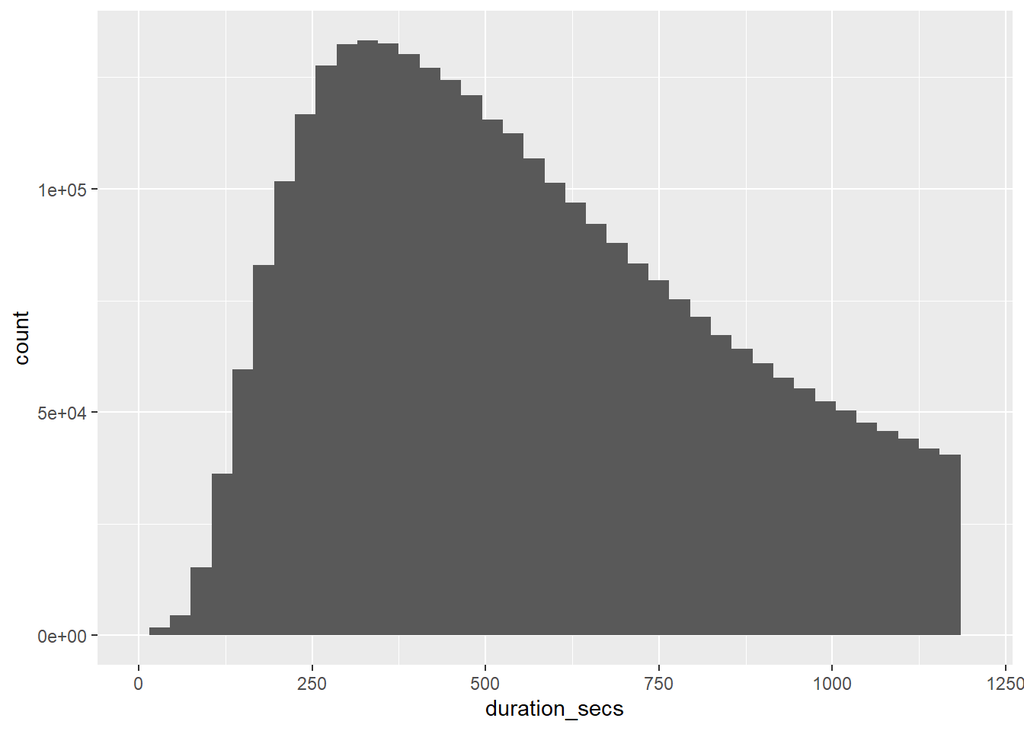

```r
# Histogram of Number of Trips vs Trip Duration (sec)

all_trips_19_20_3 %>%
  mutate(duration_secs = as.numeric(end_time - start_time, "secs")) %>%
  ggplot(aes(x = duration_secs)) +
  geom_histogram(binwidth = 30) +
  xlim(0, 1200)
```

We can see from the Histogram that in the first 60 seconds ie; 2 steps in the graph ( 1 step = 30 sec), there is no significant Trip count - which means that the first 60 seconds is Noise in the data.

So I will be removing the data in which the duration is below 60 sec.

- *(Manipulation_8) Remove the rows with Trip duration (end_time - start_time) below 60 seconds and store the new dataframe as ‘all_trips_19_20_4’.*

```r
# Remove the rows with Trip duration (end_time - start_time) below 60 seconds and store the new dataframe as 'all_trips_19_20_4'

all_trips_19_20_4 <- all_trips_19_20_3 %>%
  filter(as.numeric(end_time - start_time, "secs") >= 60)

# Number of rows removed :

nrow(all_trips_19_20_3) - nrow(all_trips_19_20_4)
```

```
## [1] 7543
```

```r
# Check if there is any rows with Trip duration below 60 seconds

all_trips_19_20_4 %>%
  mutate(duration_sec = as.numeric(end_time - start_time, "secs")) %>%
  filter(duration_sec < 60) %>%
  select(trip_id, start_time, end_time, duration_sec) %>%
  arrange(duration_sec)
```

```
## # A tibble: 0 × 4
## # ℹ 4 variables: trip_id <chr>, start_time <dttm>, end_time <dttm>,
## #   duration_sec <dbl>
```

- Cleaned all Data inconsistencies in the table.

**3) Checking for any data range errors : ✅**

1. **Check for data range errors in the ‘birth_year’ column**

```r
# Check if there are any riders with age below 16 or above 90 years

all_trips_19_20_4 %>%
  filter(as.numeric(year(start_time) - birth_year) > 90 | as.numeric(year(start_time) - birth_year) < 16 ) %>%
  arrange(desc(birth_year)) %>%
  glimpse()
```

```
## Rows: 1,037
## Columns: 11
## $ trip_id            <chr> "22463474", "22483110", "22634065", "23679951", "23…
## $ bike_id            <dbl> 6225, 6391, 2076, 3458, 6211, 1797, 1081, 5286, 438…
## $ start_time         <dttm> 2019-04-26 17:20:58, 2019-04-29 18:44:12, 2019-05-…
## $ end_time           <dttm> 2019-04-26 19:21:07, 2019-04-29 19:59:27, 2019-05-…
## $ start_station_id   <dbl> 204, 421, 204, 236, 341, 97, 309, 309, 464, 464, 46…
## $ start_station_name <chr> "Prairie Ave & Garfield Blvd", "MLK Jr Dr & 56th St…
## $ end_station_id     <dbl> 421, 421, 421, 341, 291, 100, 260, 260, 464, 464, 2…
## $ end_station_name   <chr> "MLK Jr Dr & 56th St (*)", "MLK Jr Dr & 56th St (*)…
## $ gender             <fct> Female, Female, Female, NA, NA, NA, Male, Male, Mal…
## $ birth_year         <dbl> 2014, 2014, 2014, 1928, 1928, 1928, 1925, 1925, 192…
## $ user_type          <fct> member, member, member, casual, casual, casual, cas…
```

We can see that there are 1037 riders with age below 16, and riders with age above 90 - which is an Anomaly.

Let’s remove those anomalies.

- *(Manipulation_9) Remove all the rows with birth_years corresponding to ages below 16 and above 90 from ‘all_trips_19_20_4’, and store the new dataframe as ‘all_trips_19_20_5’ .*

```r
# Remove all the rows with birth_years corresponding to ages below 16 and above 90 from 'all_trips_19_20_4', and store the new dataframe as 'all_trips_19_20_5'

all_trips_19_20_5 <- all_trips_19_20_4 %>%
  filter(is.na(birth_year) | !((year(start_time) - birth_year) > 90 | as.numeric(year(start_time) - birth_year) < 16))

# Verify the Operation

all_trips_19_20_5 %>%
  filter(as.numeric(year(start_time) - birth_year) > 90 | as.numeric(year(start_time) - birth_year) < 16 ) %>%
  arrange(desc(birth_year)) %>%
  glimpse()
```

```
## Rows: 0
## Columns: 11
## $ trip_id            <chr>
## $ bike_id            <dbl>
## $ start_time         <dttm>
## $ end_time           <dttm>
## $ start_station_id   <dbl>
## $ start_station_name <chr>
## $ end_station_id     <dbl>
## $ end_station_name   <chr>
## $ gender             <fct>
## $ birth_year         <dbl>
## $ user_type          <fct>
```

```r
# Find how many rows were removed

nrow(all_trips_19_20_4) - nrow(all_trips_19_20_5)
```

```
## [1] 1037
```

- Cleaned all Data range errors in the table.

**4) Checking for missing values / textual errors : ✅**

1. **Check for missing values the columns of ‘factor’ datatype (gender, user_type) -**

```r
all_trips_19_20_5 %>%
  distinct(gender)
```

```
## # A tibble: 3 × 1
##   gender
##   <fct>
## 1 Male
## 2 Female
## 3 <NA>
```

```r
all_trips_19_20_5 %>%
  distinct(user_type)
```

```
## # A tibble: 2 × 1
##   user_type
##   <fct>
## 1 member
## 2 casual
```

- ‘user_type’ has it’s necessary distinct categories “member”, “casual” - which means no textual errors or missing values in that column.
- ‘gender’ field has 3 distinct categories. One category is that of missing value ie; ‘NA’.

**Investigating into the missing values in ‘gender’ column :**

```r
all_trips_19_20_5 %>%
  filter(is.na(gender)) %>%
  glimpse()
```

```
## Rows: 977,102
## Columns: 11
## $ trip_id            <chr> "21742463", "21742465", "21742494", "21742498", "21…
## $ bike_id            <dbl> 3914, 3355, 2517, 374, 1776, 341, 4507, 628, 4333, …
## $ start_time         <dttm> 2019-01-01 00:29:19, 2019-01-01 00:29:28, 2019-01-…
## $ end_time           <dttm> 2019-01-01 01:08:12, 2019-01-01 01:07:49, 2019-01-…
## $ start_station_id   <dbl> 35, 35, 290, 367, 367, 316, 316, 260, 35, 35, 318, …
## $ start_station_name <chr> "Streeter Dr & Grand Ave", "Streeter Dr & Grand Ave…
## $ end_station_id     <dbl> 39, 39, 476, 9, 9, 457, 457, 240, 37, 37, 229, 282,…
## $ end_station_name   <chr> "Wabash Ave & Adams St", "Wabash Ave & Adams St", "…
## $ gender             <fct> NA, NA, NA, NA, NA, NA, NA, NA, NA, NA, NA, NA, NA,…
## $ birth_year         <dbl> NA, NA, NA, NA, NA, NA, NA, NA, NA, NA, NA, NA, NA,…
## $ user_type          <fct> casual, casual, casual, casual, casual, casual, cas…
```

There are approx. 1 Million rows of missing values out of approx. 4 million total rows.

2. **And, ‘birth_year’ also seems to have missing values. Let’s check that too.**

```r
all_trips_19_20_5 %>%
  filter(is.na(birth_year)) %>%
  glimpse()
```

```
## Rows: 956,712
## Columns: 11
## $ trip_id            <chr> "21742463", "21742465", "21742494", "21742498", "21…
## $ bike_id            <dbl> 3914, 3355, 2517, 374, 1776, 341, 4507, 628, 4333, …
## $ start_time         <dttm> 2019-01-01 00:29:19, 2019-01-01 00:29:28, 2019-01-…
## $ end_time           <dttm> 2019-01-01 01:08:12, 2019-01-01 01:07:49, 2019-01-…
## $ start_station_id   <dbl> 35, 35, 290, 367, 367, 316, 316, 260, 35, 35, 318, …
## $ start_station_name <chr> "Streeter Dr & Grand Ave", "Streeter Dr & Grand Ave…
## $ end_station_id     <dbl> 39, 39, 476, 9, 9, 457, 457, 240, 37, 37, 229, 282,…
## $ end_station_name   <chr> "Wabash Ave & Adams St", "Wabash Ave & Adams St", "…
## $ gender             <fct> NA, NA, NA, NA, NA, NA, NA, NA, NA, NA, NA, NA, NA,…
## $ birth_year         <dbl> NA, NA, NA, NA, NA, NA, NA, NA, NA, NA, NA, NA, NA,…
## $ user_type          <fct> casual, casual, casual, casual, casual, casual, cas…
```

In ‘birth_year’ column too, there are approx. 1 Million rows of missing values.

3. **Check the bike_id column for missing values :**

```r
all_trips_19_20_5 %>%
  filter(is.na(bike_id)) %>%
  glimpse()
```

```
## Rows: 418,911
## Columns: 11
## $ trip_id            <chr> "EACB19130B0CDA4A", "8FED874C809DC021", "789F3C21E4…
## $ bike_id            <dbl> NA, NA, NA, NA, NA, NA, NA, NA, NA, NA, NA, NA, NA,…
## $ start_time         <dttm> 2020-01-21 20:06:59, 2020-01-30 14:22:39, 2020-01-…
## $ end_time           <dttm> 2020-01-21 20:14:30, 2020-01-30 14:26:22, 2020-01-…
## $ start_station_id   <dbl> 239, 234, 296, 51, 66, 212, 96, 96, 212, 38, 117, 1…
## $ start_station_name <chr> "Western Ave & Leland Ave", "Clark St & Montrose Av…
## $ end_station_id     <dbl> 326, 318, 117, 24, 212, 96, 212, 212, 96, 100, 632,…
## $ end_station_name   <chr> "Clark St & Leland Ave", "Southport Ave & Irving Pa…
## $ gender             <fct> NA, NA, NA, NA, NA, NA, NA, NA, NA, NA, NA, NA, NA,…
## $ birth_year         <dbl> NA, NA, NA, NA, NA, NA, NA, NA, NA, NA, NA, NA, NA,…
## $ user_type          <fct> member, member, member, member, member, member, mem…
```

There are approx. 0.4 Million rows with missing values in bike_id. But there are approx. 3.5 million or more data with accurate data. As I couldn’t find consistent data to fill these missing fields, I will be keeping it as is. I will be keeping this information in the back of my mind while doing analysis.

4. **Check if any other columns have missing values :**

```r
all_trips_19_20_5 %>%
  filter(is.na(trip_id) |
           is.na(start_time) |
           is.na(end_time) |
           is.na(start_station_id) |
           is.na(start_station_name) |
           is.na(end_station_id) |
           is.na(end_station_name) |
           is.na(user_type)) %>%
  glimpse()
```

```
## Rows: 0
## Columns: 11
## $ trip_id            <chr>
## $ bike_id            <dbl>
## $ start_time         <dttm>
## $ end_time           <dttm>
## $ start_station_id   <dbl>
## $ start_station_name <chr>
## $ end_station_id     <dbl>
## $ end_station_name   <chr>
## $ gender             <fct>
## $ birth_year         <dbl>
## $ user_type          <fct>
```

That’s it for Organizing and Cleaning the data.

### **Changelog :**

👉[Click here to view the Changelog](https://docs.google.com/document/d/18zyK9TFA0BY8_LiS-mG935c3jkJ4hr1F7vXocNGYBWg/edit?usp=sharing)

Summary of the Process phase -

## 4. ANALYZE PHASE (Deliverable = Summary of Analysis)

### Calculation :

Now, let’s calculate all the necessary data that we need :

**a) trip_duration**

- *(Manipulation_10) Calculate Trip duration as the variable trip_duration. Save the new dataframe as all_trips_19_20_6.*

```r
# Calculate Trip duration as the variable trip_duration. Save the new dataframe as all_trips_19_20_6

all_trips_19_20_6 <- all_trips_19_20_5 %>%
  mutate(trip_duration = as.numeric(end_time - start_time, "secs")) %>%
  arrange(trip_duration)

# View 'all_trips_19_20_6'

str(all_trips_19_20_6)
```

```
## tibble [4,233,914 × 12] (S3: tbl_df/tbl/data.frame)
##  $ trip_id           : chr [1:4233914] "B9ED9D8CE75F542B" "7DC888EB586ED128" "681409CD394F390A" "C0600AA879AFE630" ...
##  $ bike_id           : num [1:4233914] NA NA NA NA NA NA NA NA NA NA ...
##  $ start_time        : POSIXct[1:4233914], format: "2020-01-26 01:51:36" "2020-01-07 15:56:04" ...
##  $ end_time          : POSIXct[1:4233914], format: "2020-01-26 01:52:36" "2020-01-07 15:57:04" ...
##  $ start_station_id  : num [1:4233914] 41 174 174 291 91 14 198 164 197 238 ...
##  $ start_station_name: chr [1:4233914] "Federal St & Polk St" "Canal St & Madison St" "Canal St & Madison St" "Wells St & Evergreen Ave" ...
##  $ end_station_id    : num [1:4233914] 394 77 77 291 77 14 198 164 197 238 ...
##  $ end_station_name  : chr [1:4233914] "Clark St & 9th St (AMLI)" "Clinton St & Madison St" "Clinton St & Madison St" "Wells St & Evergreen Ave" ...
##  $ gender            : Factor w/ 2 levels "Female","Male": NA NA NA NA NA NA NA NA NA NA ...
##  $ birth_year        : num [1:4233914] NA NA NA NA NA NA NA NA NA NA ...
##  $ user_type         : Factor w/ 2 levels "casual","member": 2 2 2 2 2 2 2 2 2 2 ...
##  $ trip_duration     : num [1:4233914] 60 60 60 60 60 60 60 60 60 60 ...
```

**b) week_day**

- *(Manipulation_11) Calculate Day of the week as the variable week_day. Save the new dataframe as all_trips_19_20_7.*

```r
# Calculate Day of the week as the variable week_day. Save the new dataframe as all_trips_19_20_7

all_trips_19_20_7 <- all_trips_19_20_6 %>%
  mutate(week_day = wday(start_time, label = TRUE, abbr = TRUE))


# View 'all_trips_19_20_7'

skim_without_charts(all_trips_19_20_7)
```

Data summary

| Name | all_trips_19_20_7 |
| --- | --- |
| Number of rows | 4233914 |
| Number of columns | 13 |
| _______________________ |  |
| Column type frequency: |  |
| character | 3 |
| factor | 3 |
| numeric | 5 |
| POSIXct | 2 |
| ________________________ |  |
| Group variables | None |

**Variable type: character**

| skim_variable | n_missing | complete_rate | min | max | empty | n_unique | whitespace |
| --- | --- | --- | --- | --- | --- | --- | --- |
| trip_id | 0 | 1 | 7 | 16 | 0 | 4233914 | 0 |
| start_station_name | 0 | 1 | 5 | 43 | 0 | 643 | 0 |
| end_station_name | 0 | 1 | 5 | 43 | 0 | 644 | 0 |

**Variable type: factor**

| skim_variable | n_missing | complete_rate | ordered | n_unique | top_counts |
| --- | --- | --- | --- | --- | --- |
| gender | 977102 | 0.77 | FALSE | 2 | Mal: 2399200, Fem: 857612 |
| user_type | 0 | 1.00 | FALSE | 2 | mem: 3310385, cas: 923529 |
| week_day | 0 | 1.00 | TRUE | 7 | Tue: 658968, Thu: 652542, Wed: 652142, Fri: 637177 |

**Variable type: numeric**

| skim_variable | n_missing | complete_rate | mean | sd | p0 | p25 | p50 | p75 | p100 |
| --- | --- | --- | --- | --- | --- | --- | --- | --- | --- |
| bike_id | 418911 | 0.90 | 3380.25 | 1902.49 | 1 | 1727 | 3451 | 5046 | 6946 |
| start_station_id | 0 | 1.00 | 202.02 | 156.25 | 1 | 77 | 174 | 289 | 675 |
| end_station_id | 0 | 1.00 | 202.82 | 156.35 | 1 | 77 | 174 | 291 | 675 |
| birth_year | 956712 | 0.77 | 1984.10 | 10.78 | 1929 | 1979 | 1987 | 1992 | 2003 |
| trip_duration | 0 | 1.00 | 1116.11 | 2082.95 | 60 | 402 | 692 | 1250 | 86385 |

**Variable type: POSIXct**

| skim_variable | n_missing | complete_rate | min | max | median | n_unique |
| --- | --- | --- | --- | --- | --- | --- |
| start_time | 0 | 1 | 2019-01-01 00:04:37 | 2020-03-31 23:51:34 | 2019-08-05 07:52:58 | 3695904 |
| end_time | 0 | 1 | 2019-01-01 00:11:07 | 2020-04-01 07:38:49 | 2019-08-05 08:06:14 | 3628412 |

**c) month_name**

- *(Manipulation_12) Calculate the Months of the year as the variable month_name. Save the new dataframe as all_trips_19_20_8.*

```r
# Calculate the Months of the year as the variable month_name. Save the new dataframe as all_trips_19_20_8.

all_trips_19_20_8 <- all_trips_19_20_7 %>%
  mutate(month_name = month(start_time, label = TRUE, abbr = TRUE))

# View 'all_trips_19_20_8'

glimpse(all_trips_19_20_8)
```

```
## Rows: 4,233,914
## Columns: 14
## $ trip_id            <chr> "B9ED9D8CE75F542B", "7DC888EB586ED128", "681409CD39…
## $ bike_id            <dbl> NA, NA, NA, NA, NA, NA, NA, NA, NA, NA, NA, NA, NA,…
## $ start_time         <dttm> 2020-01-26 01:51:36, 2020-01-07 15:56:04, 2020-01-…
## $ end_time           <dttm> 2020-01-26 01:52:36, 2020-01-07 15:57:04, 2020-01-…
## $ start_station_id   <dbl> 41, 174, 174, 291, 91, 14, 198, 164, 197, 238, 199,…
## $ start_station_name <chr> "Federal St & Polk St", "Canal St & Madison St", "C…
## $ end_station_id     <dbl> 394, 77, 77, 291, 77, 14, 198, 164, 197, 238, 199, …
## $ end_station_name   <chr> "Clark St & 9th St (AMLI)", "Clinton St & Madison S…
## $ gender             <fct> NA, NA, NA, NA, NA, NA, NA, NA, NA, NA, NA, NA, NA,…
## $ birth_year         <dbl> NA, NA, NA, NA, NA, NA, NA, NA, NA, NA, NA, NA, NA,…
## $ user_type          <fct> member, member, member, member, member, member, mem…
## $ trip_duration      <dbl> 60, 60, 60, 60, 60, 60, 60, 60, 60, 60, 60, 60, 60,…
## $ week_day           <ord> Sun, Tue, Wed, Wed, Wed, Tue, Mon, Wed, Mon, Fri, T…
## $ month_name         <ord> Jan, Jan, Jan, Jan, Jan, Jan, Jan, Jan, Jan, Jan, F…
```

**d) bike_route**

- *(Manipulation_13) Calculate the route (station pair) as the variable bike_route. Save the new dataframe as all_trips_19_20_9.*

```r
# Calculate the route (station pair) as the variable bike_route. Save the new dataframe as all_trips_19_20_9.

all_trips_19_20_9 <- all_trips_19_20_8 %>%
  mutate(bike_route = paste0(start_station_name, " - ", end_station_name))

# View 'all_trips_19_20_9'

glimpse(all_trips_19_20_9)
```

```
## Rows: 4,233,914
## Columns: 15
## $ trip_id            <chr> "B9ED9D8CE75F542B", "7DC888EB586ED128", "681409CD39…
## $ bike_id            <dbl> NA, NA, NA, NA, NA, NA, NA, NA, NA, NA, NA, NA, NA,…
## $ start_time         <dttm> 2020-01-26 01:51:36, 2020-01-07 15:56:04, 2020-01-…
## $ end_time           <dttm> 2020-01-26 01:52:36, 2020-01-07 15:57:04, 2020-01-…
## $ start_station_id   <dbl> 41, 174, 174, 291, 91, 14, 198, 164, 197, 238, 199,…
## $ start_station_name <chr> "Federal St & Polk St", "Canal St & Madison St", "C…
## $ end_station_id     <dbl> 394, 77, 77, 291, 77, 14, 198, 164, 197, 238, 199, …
## $ end_station_name   <chr> "Clark St & 9th St (AMLI)", "Clinton St & Madison S…
## $ gender             <fct> NA, NA, NA, NA, NA, NA, NA, NA, NA, NA, NA, NA, NA,…
## $ birth_year         <dbl> NA, NA, NA, NA, NA, NA, NA, NA, NA, NA, NA, NA, NA,…
## $ user_type          <fct> member, member, member, member, member, member, mem…
## $ trip_duration      <dbl> 60, 60, 60, 60, 60, 60, 60, 60, 60, 60, 60, 60, 60,…
## $ week_day           <ord> Sun, Tue, Wed, Wed, Wed, Tue, Mon, Wed, Mon, Fri, T…
## $ month_name         <ord> Jan, Jan, Jan, Jan, Jan, Jan, Jan, Jan, Jan, Jan, F…
## $ bike_route         <chr> "Federal St & Polk St - Clark St & 9th St (AMLI)", …
```

**e) rider_age**

- *(Manipulation_14) Calculate the rider age as the variable rider_age. Save the new dataframe as all_trips_19_20_10.*

```r
# Calculate the rider age as the variable rider_age. Save the new dataframe as all_trips_19_20_10.

all_trips_19_20_10 <- all_trips_19_20_9 %>%
  mutate(rider_age = year(start_time) - birth_year)

# View 'all_trips_19_20_10'

glimpse(all_trips_19_20_10)
```

```
## Rows: 4,233,914
## Columns: 16
## $ trip_id            <chr> "B9ED9D8CE75F542B", "7DC888EB586ED128", "681409CD39…
## $ bike_id            <dbl> NA, NA, NA, NA, NA, NA, NA, NA, NA, NA, NA, NA, NA,…
## $ start_time         <dttm> 2020-01-26 01:51:36, 2020-01-07 15:56:04, 2020-01-…
## $ end_time           <dttm> 2020-01-26 01:52:36, 2020-01-07 15:57:04, 2020-01-…
## $ start_station_id   <dbl> 41, 174, 174, 291, 91, 14, 198, 164, 197, 238, 199,…
## $ start_station_name <chr> "Federal St & Polk St", "Canal St & Madison St", "C…
## $ end_station_id     <dbl> 394, 77, 77, 291, 77, 14, 198, 164, 197, 238, 199, …
## $ end_station_name   <chr> "Clark St & 9th St (AMLI)", "Clinton St & Madison S…
## $ gender             <fct> NA, NA, NA, NA, NA, NA, NA, NA, NA, NA, NA, NA, NA,…
## $ birth_year         <dbl> NA, NA, NA, NA, NA, NA, NA, NA, NA, NA, NA, NA, NA,…
## $ user_type          <fct> member, member, member, member, member, member, mem…
## $ trip_duration      <dbl> 60, 60, 60, 60, 60, 60, 60, 60, 60, 60, 60, 60, 60,…
## $ week_day           <ord> Sun, Tue, Wed, Wed, Wed, Tue, Mon, Wed, Mon, Fri, T…
## $ month_name         <ord> Jan, Jan, Jan, Jan, Jan, Jan, Jan, Jan, Jan, Jan, F…
## $ bike_route         <chr> "Federal St & Polk St - Clark St & 9th St (AMLI)", …
## $ rider_age          <dbl> NA, NA, NA, NA, NA, NA, NA, NA, NA, NA, NA, NA, NA,…
```

### Descriptive analysis :

*Note :*

Most busy => Highest total trip count

Least busy => Least total trip count

**1. Trip duration by Usertype :**

1. **Maximum, Minimum, Average -**

```r
# Trip duration statistics

trip_duration_stat <- all_trips_19_20_10 %>%
  group_by(user_type) %>%
  summarise('maximum_duration (minutes)' = max(trip_duration)/60, 'minimum_duration (minutes)' = min(trip_duration)/60, 'average_duration (minutes)' = mean(trip_duration)/60)

# View

head(trip_duration_stat)
```

```
## # A tibble: 2 × 4
##   user_type maximum_duration (mi…¹ minimum_duration (mi…² average_duration (mi…³
##   <fct>                      <dbl>                  <dbl>                  <dbl>
## 1 casual                     1439.                   1.02                   39.5
## 2 member                     1440.                   1                      12.8
## # ℹ abbreviated names: ¹`maximum_duration (minutes)`,
## #   ²`minimum_duration (minutes)`, ³`average_duration (minutes)`
```

**(1A)**

1. Annual members ride an average of 12.8 minutes while Casuals ride for 39 minutes on an average.

**2. Most busy day (Mode of ‘week_day’) & Least busy day of the week (2019 - 2020 Q1):**

```r
# Summarise counts per user_type & week_day once

day_counts <- all_trips_19_20_10 %>%
  group_by(user_type, week_day) %>%
  summarise(trip_count = n(), .groups = 'drop')

# Find busiest day per user_type

busiest <- day_counts %>%
  group_by(user_type) %>%
  slice_max(trip_count, n = 1, with_ties = FALSE) %>%
  select(user_type, busiest_day = week_day, busiest_trip_count = trip_count)

# Find least busy day per user_type

least_busy <- day_counts %>%
  group_by(user_type) %>%
  slice_min(trip_count, n = 1, with_ties = FALSE) %>%
  select(user_type, least_busy_day = week_day, least_busy_trip_count = trip_count)

# Join busiest and least busy by user_type

most_least_busy_day <- busiest %>%
  inner_join(least_busy, by = "user_type")

# View the summary

head(most_least_busy_day)
```

```
## # A tibble: 2 × 5
## # Groups:   user_type [2]
##   user_type busiest_day busiest_trip_count least_busy_day least_busy_trip_count
##   <fct>     <ord>                    <int> <ord>                          <int>
## 1 casual    Sat                     215174 Tue                            93035
## 2 member    Tue                     565933 Sun                           291600
```

**(2A)**

1. Casual riders : Saturday is the most busy day, while Tuesday is the least busy day
2. Annual members : Tuesday is the most busy day, while Sunday is the least busy day

### Analysis Summaries :

- Blue Ocean Action plan = Raise the resources on high leverage activities, Create high leverage activities, Reduce resources on low leverage activities, Remove the low leverage activities
  - Always summarize every analysis keeping this Action plan in mind.

#### The ‘Whole’ method of analysis :

‘Whole’ method equation = (V1, V2, V3,..) x CoreC0.(Combination(C1, C2, C3,…)) *where, V = Value, C = Category, CoreC0 = Core category*

Prioritizing categories :

1. Time (Wide, then narrow. Eg; Month, then Weekday)
2. Location (Wide, then narrow. Eg; Station, then Route.)
3. User_characteristics

**Eg;**

(V1) x CoreC0.(Combination(C1, C2, C3)) = V1.C1, V1.C1.C2, V1.C1.C3, V1.C1.C2.C3; V1.C2, V1.C2.C3; V1.C3 (Every combination has C0 in it.)

Here, (Trip count, Trip duration) x *user_type.*(month_name, week_day, start_station_name, bike_route, gender, rider_age)

**1. V1 = Total Trip count**

*a1)* What is the day with the highest trip count for Casual riders and Annual members respectively.

2. month, station, route, gender, age (5C1 = 5)
3. month-station, month-route, month-gender, month-age, station-route, station-gender, station-age, route-gender, route-age, gender-age (5C2 = 10)
4. month-station-route, month-station-gender, month-station-age, month-route-gender, month-route-age, month-gender-age, station-route-gender, station-route-age, station-gender-age, route-gender-age (5C3 = 10)
5. month-station-route-gender, month-station-route-age, month-station-gender-age, month-route-gender-age, station-route-gender-age (5C4 = 5)
6. month-station-route-gender-age (5C5 = 1)

*a2)* month

2. station, route, gender, age (4C1 = 4)
3. station-route, station-gender, station-age, route-gender, router-age, gender-age (4C2 = 6)
4. station-route-gender, station-router-age, station-gender-age, route-gender-age (4C3 = 4)
5. station-route-gender-age (4C4 = 1)

*a3)* station

2. route, gender, age
3. route-gender, route-age, gender-age
4. route-gender-age

*a4)* route

2. gender, age
3. gender-age

*a5)* gender

2. age

*a6)* age

**2. V2 = Total trip duration**

- same pattern as above

**3. V3 = Average trip duration**

- same pattern as above

#### ‘Wide to Narrow’ method of analysis :

The above method is complicated, but keep it’s logic in your mind. And use this method instead - for faster & efficient analysis.

Imagine going from Wide to narrow in category for each Value (V).

V1 : Trip count

C0 : Core category

Eg;

1. First, look at Wider time ie; Monthly patterns. **V1 x C0 x C1**
2. Then, Narrower ie; Weekday patterns ( Analyse the weekdays only after knowing which months have high count, low count, what the monthly patterns are…) **V1 x C0 x C2**
3. Then, Wider location ie; Stations’ patterns (Analyse the stations only after analyzing the patterns and summaries of it’s parent ie; Weekdays, Months) **V1 x C0 x C3**
4. Then, Narrower, ie; Routes’ patterns (Analyse the Routes only after knowing the patterns of it’s parent ie; Stations) **V1 x C0 x C4**
5. Then, User_characteristic patterns (Analyse this only after building a connection with all the above categories in a Hierarchical manner on the Value you are evaluating.) **V1 x C0 x C5**

Don’t complicate the analysis by combining the Categories. We only need a single category combined with the Core category (Here, Core category = user_type). And then, just do this *Hierarchical analysis* and find the Relation between categories by connecting the dots hierarchically.

Similar process for other Values.

Eg; All the analyses done below is using this methodology. For better understanding, Keep attention ahead !

Now that we know the system to do the analysis, let’s go ahead and do it.

#### 1. Trip count -

*0) Total number of trips by Usertype (2019 - 2020 Q1) :*

```r
# Total number of trips by Usertype

summary0_df <- all_trips_19_20_10 %>%
  group_by(user_type) %>%
  summarise(total_trip_count = n())

# View the summary

head(summary0_df)
```

```
## # A tibble: 2 × 2
##   user_type total_trip_count
##   <fct>                <int>
## 1 casual              923529
## 2 member             3310385
```

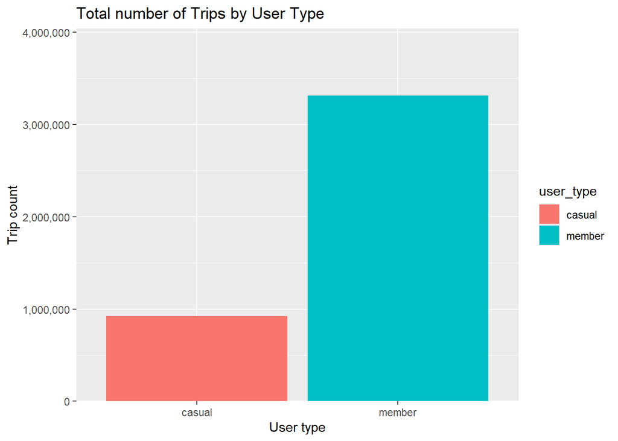

```r
# Total number of trips by Usertype - Column graph

ggplot(data = summary0_df,
       mapping = aes(x = user_type,
                     y = total_trip_count,
                     fill = user_type)) +
  geom_col() +
  labs(title = "Total number of Trips by User Type",
       x = "User type",
       y = "Trip count") +
  scale_y_continuous(limits = c(0, 4000000),
                     labels = scales::comma,
                     expand = expansion(mult = c(0, 0.01)))
```

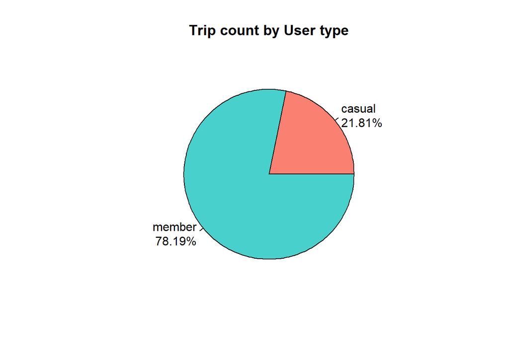

```r
# Percentage number of trips by Usertype - Pie graph

summary0_df <- summary0_df %>%
  mutate(percentage_trip_count = total_trip_count/sum(total_trip_count)*100)

annotation0 <- paste0(summary0_df$user_type, "\n",
                      round(summary0_df$percentage_trip_count,2), "%")

pie(summary0_df$percentage_trip_count,
    labels = annotation0,
    col = c("salmon", "mediumturquoise"),
    main = "Trip count by User type")
```

**(3A)**

1. Casual riders : Trip count is approx. 0.92 Million, which is 22% of the Total trip count.
2. Annual members : Trip count is approx. 3.3 Million, which is 78% of the Total trip count.

```r
# Total number of trips in a Month by Usertype

summary1_df <- all_trips_19_20_10 %>%
  filter(year(start_time) == 2019) %>%
  group_by(month_name, user_type) %>%
  summarize(
    total_trip_count = n()
    )
# Summary wide table view

glimpse(summary1_df %>% pivot_wider(
    names_from = month_name,
    values_from = c(total_trip_count)))
```

```
## Rows: 2
## Columns: 13
## $ user_type <fct> casual, member
## $ Jan       <int> 4589, 98554
## $ Feb       <int> 2627, 93463
## $ Mar       <int> 15877, 149596
## $ Apr       <int> 47665, 217454
## $ May       <int> 81505, 285730
## $ Jun       <int> 130061, 345068
## $ Jul       <int> 175408, 381414
## $ Aug       <int> 186613, 403117
## $ Sep       <int> 128985, 363879
## $ Oct       <int> 70887, 300586
## $ Nov       <int> 18653, 158314
## $ Dec       <int> 16365, 138593
```

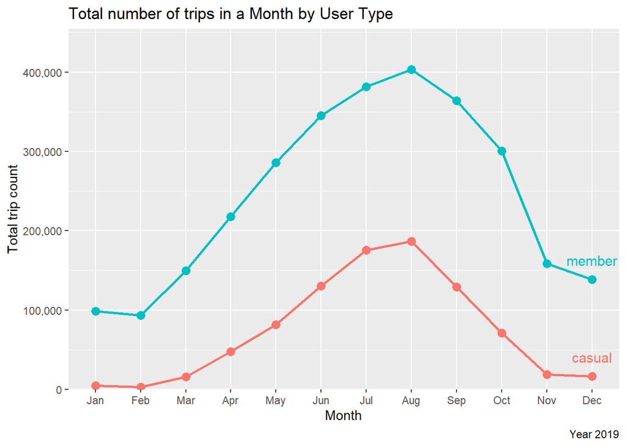

```r
# Total number of trips in a Month by Usertype - Line plot

label_data_1 <- summary1_df %>%
  filter(month_name == "Dec")

ggplot(data = summary1_df,
       mapping = aes(x = month_name,
                     y = total_trip_count,
                     colour = user_type,
                     group = user_type)) +
  geom_line(size =  1) +
  geom_point(size = 3) +
  labs(title = "Total number of trips in a Month by User Type",
       x = "Month",
       y = "Total trip count",
       caption = "Year 2019") +
  geom_text(data = label_data_1,
            aes(label = user_type),
            vjust = -1.3,
            size = 4,
            show.legend = FALSE) +
  scale_y_continuous(limits = c(0, 450000),
                     labels = scales::comma,
                     expand = expansion(mult = c(0, 0.01))) +
  theme(legend.position = "none")
```

*2) Total number of trips in a Weekday by Usertype (2019 - 2020 Q1) :*

```r
# Total number of trips in a Weekday by Usertype

summary2_df <- all_trips_19_20_10 %>%
  group_by(week_day, user_type) %>%
  summarize(
    total_trip_count = n()
    )
# Summary wide table view

head(summary2_df %>% pivot_wider(
    names_from = week_day,
    values_from = c(total_trip_count)))
```

```
## # A tibble: 2 × 8
##   user_type    Sun    Mon    Tue    Wed    Thu    Fri    Sat
##   <fct>      <int>  <int>  <int>  <int>  <int>  <int>  <int>
## 1 casual    184684 105015  93035  94740 105361 125520 215174
## 2 member    291600 519888 565933 557402 547181 511657 316724
```

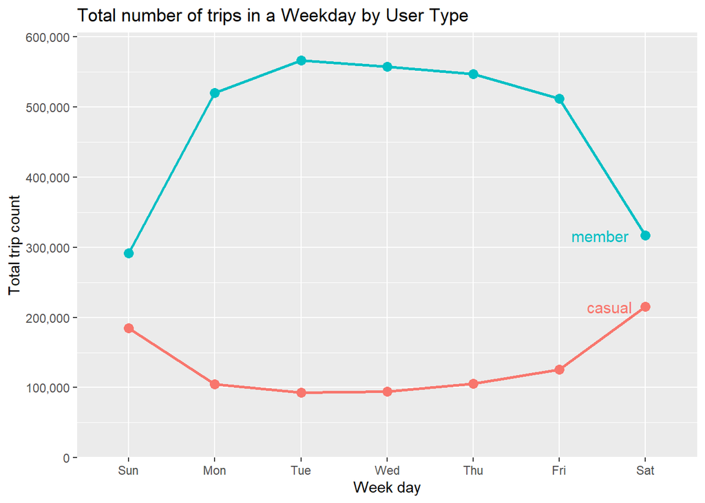

```r
# Total number of trips in a Weekday by Usertype  - Line plot

label_data_2 <- summary2_df %>%
  filter(week_day == "Sat")

ggplot(data = summary2_df,
       mapping = aes(x = week_day,
                     y = total_trip_count,
                     colour = user_type,
                     group = user_type)) +
  geom_line(size =  1) +
  geom_point(size = 3) +
  labs(title = "Total number of trips in a Weekday by User Type",
       x = "Week day",
       y = "Total trip count") +
  geom_text(data = label_data_2,
            aes(label = user_type),
            hjust = 1.3,
            size = 4,
            show.legend = FALSE) +
  scale_y_continuous(limits = c(0, 600000),
                     labels = scales::comma,
                     expand = expansion(mult = c(0, 0.01))) +
  theme(legend.position = "none")
```

*3) Total number of trips in a Station by Usertype (2019 - 2020 Q1) :*

- **Let’s look at the Top 20 Stations by Trip count & User type.**

```r
# Total number of trips from a Station by Usertype : Top 20 Stations

summary3_df <- all_trips_19_20_10 %>%
  group_by(start_station_name, user_type) %>%
  summarize(
    total_trip_count = n()
    ) %>%
  group_by(user_type) %>%
  slice_max(order_by = total_trip_count, n = 20)
# Summary long table view

glimpse(summary3_df %>% pivot_wider(
    names_from = user_type,
    values_from = c(total_trip_count)) %>%
      arrange(desc(casual)))
```

```
## Rows: 38
## Columns: 3
## $ start_station_name <chr> "Streeter Dr & Grand Ave", "Lake Shore Dr & Monroe …
## $ casual             <int> 54582, 40793, 22503, 21998, 21604, 19331, 15582, 13…
## $ member             <int> NA, NA, NA, NA, NA, NA, NA, NA, 28488, NA, NA, NA, …
```

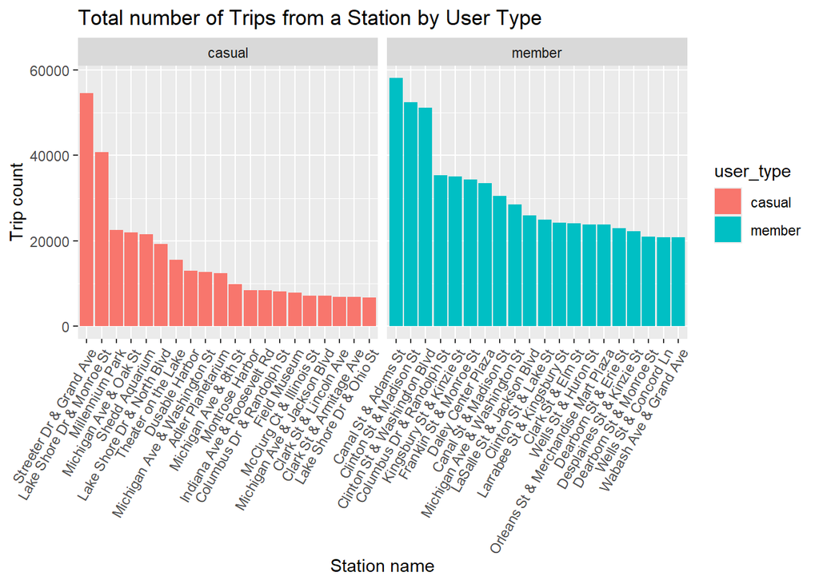

```r
# Total number of trips from a Station by Usertype : Top 20 stations

ggplot(summary3_df, aes(x = reorder_within(start_station_name, -total_trip_count, user_type),
                        y = total_trip_count,
                        fill = user_type)) +
  geom_col(position = "identity") +
  labs(title = "Total number of Trips from a Station by User Type",
       x = "Station name",
       y = "Trip count") +
  theme(axis.text.x = element_text(angle = 60, hjust = 1))+
  scale_x_reordered() +
  facet_wrap(~user_type, scales = "free_x")
```

- **So let’s look at only the *Top 10 Stations for Trip count.***

```r
# Total number of trips from a Station by Usertype : Top 10 Stations

summary4_df <- all_trips_19_20_10 %>%
  group_by(start_station_name, user_type) %>%
  summarize(
    total_trip_count = n()
    ) %>%
  group_by(user_type) %>%
  slice_max(order_by = total_trip_count, n = 10)
# Summary long table view

glimpse(summary4_df %>% pivot_wider(
    names_from = user_type,
    values_from = c(total_trip_count)) %>%
      arrange(desc(member)))
```

```
## Rows: 19
## Columns: 3
## $ start_station_name <chr> "Canal St & Adams St", "Clinton St & Madison St", "…
## $ casual             <int> NA, NA, NA, NA, NA, NA, NA, NA, 12709, NA, 54582, 4…
## $ member             <int> 58086, 52415, 51133, 35415, 35104, 34361, 33485, 30…
```

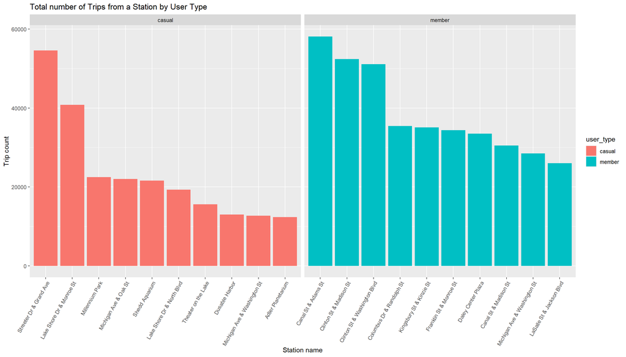

```r
# Top 10 Stations by Trip count  - Column chart

ggplot(summary4_df, aes(x = reorder_within(start_station_name, -total_trip_count, user_type),
                        y = total_trip_count,
                        fill = user_type)) +
  geom_col(position = "identity") +
  labs(title = "Total number of Trips from a Station by User Type",
       x = "Station name",
       y = "Trip count") +
  theme(axis.text.x = element_text(angle = 60, hjust = 1))+
  scale_x_reordered() +
  facet_wrap(~user_type, scales = "free_x")
```

- **Total number of trips from a Station by Casual riders : Top 10 Stations - MAP**

```r
# Total number of trips from a Station by Casual riders : Top 10 Stations - MAP

stations_df <- read.csv("top_stations_trips_geocoded.csv") # Extracted the coordinates of stations using geocode function, and then saved it in a csv file. Which then is being read now.

# Step 1: Filter casual stations and rank them
casual_stations_ranked <- stations_df %>%
  filter(user_type == "casual") %>%
  arrange(desc(total_trip_count)) %>%
  mutate(
    rank = row_number(),
    marker_size = scales::rescale(max(rank) + 1 - rank, to = c(6, 12))
  )

# Step 2: Create the map
m1 <- leaflet(casual_stations_ranked) %>%
  addProviderTiles(providers$CartoDB.Positron) %>%
  addCircleMarkers(
    ~longitude, ~latitude,
    radius = ~marker_size,
    color = "red",
    fillOpacity = 0.9,
    stroke = FALSE,
    popup = ~paste0(
      "<strong>Rank ", rank, ":</strong> ", start_station_name, "<br>",
      "Trips: ", total_trip_count
    )
  ) %>%
  addControl(
    html = paste0(
      "<div style='text-align:left; padding:8px; font-size:12px; background:white; border-radius:8px;'>",
      "<strong>Trip frequency : Top 10 Stations (Casual riders)</strong><br>",
      paste0(
        casual_stations_ranked %>%
          arrange(rank) %>%
          mutate(label = paste0(rank, ". ", start_station_name)) %>%
          pull(label),
        collapse = "<br>"
      ),
      "</div>"
    ),
    position = "topright"
  )

m1
```

[interactive chart not shown]

- **Total number of trips from a Station by Annual members : Top 10 Stations - MAP**

```r
# Total number of trips from a Station by Annual members : Top 10 Stations - MAP

# Step 1: Filter casual stations and rank them
member_stations_ranked <- stations_df %>%
  filter(user_type == "member") %>%
  arrange(desc(total_trip_count)) %>%
  mutate(
    rank = row_number(),
    marker_size = scales::rescale(max(rank) + 1 - rank, to = c(6, 12))
  )

# Step 2: Create the map
m2 <- leaflet(member_stations_ranked) %>%
  addProviderTiles(providers$CartoDB.Positron) %>%
  addCircleMarkers(
    ~longitude, ~latitude,
    radius = ~marker_size,
    color = "blue",
    fillOpacity = 0.9,
    stroke = FALSE,
    popup = ~paste0(
      "<strong>Rank ", rank, ":</strong> ", start_station_name, "<br>",
      "Trips: ", total_trip_count
    )
  ) %>%
  addControl(
    html = paste0(
      "<div style='text-align:left; padding:8px; font-size:12px; background:white; border-radius:8px;'>",
      "<strong>Trip frequency : Top 10 Stations (Annual members)</strong><br>",
      paste0(
        member_stations_ranked %>%
          arrange(rank) %>%
          mutate(label = paste0(rank, ". ", start_station_name)) %>%
          pull(label),
        collapse = "<br>"
      ),
      "</div>"
    ),
    position = "topright"
  )

m2
```

[interactive chart not shown]

**(6A)**

1. Casual riders : “Streeter Dr & Grand Axe” is the most busiest station for Casual riders. The Top 10 Busy stations are located near the Lake side.
2. Annual members : “Canal St & Adams St” is the most busiest station for Annual members. The Top 10 Busy stations are concentrated away from the Lake side.

*4) Total number of trips by Bike route and User type (2019 - 2020 Q1) :*

```r
# Total number of trips from a Bike route by Usertype : Top 10 Routes

summary5_df <- all_trips_19_20_10 %>%
  group_by(bike_route, user_type) %>%
  summarize(
    total_trip_count = n(),
    .groups = "drop") %>%
  group_by(user_type) %>%
  slice_max(order_by = total_trip_count, n = 10)

# Summary long table view

glimpse(summary5_df %>% pivot_wider(
    names_from = user_type,
    values_from = c(total_trip_count)) %>%
      arrange(desc(casual)))
```

```
## Rows: 20
## Columns: 3
## $ bike_route <chr> "Lake Shore Dr & Monroe St - Streeter Dr & Grand Ave", "Str…
## $ casual     <int> 9660, 8773, 8459, 5130, 3691, 3246, 3025, 3009, 2968, 2761,…
## $ member     <int> NA, NA, NA, NA, NA, NA, NA, NA, NA, NA, 3989, 3227, 2994, 2…
```

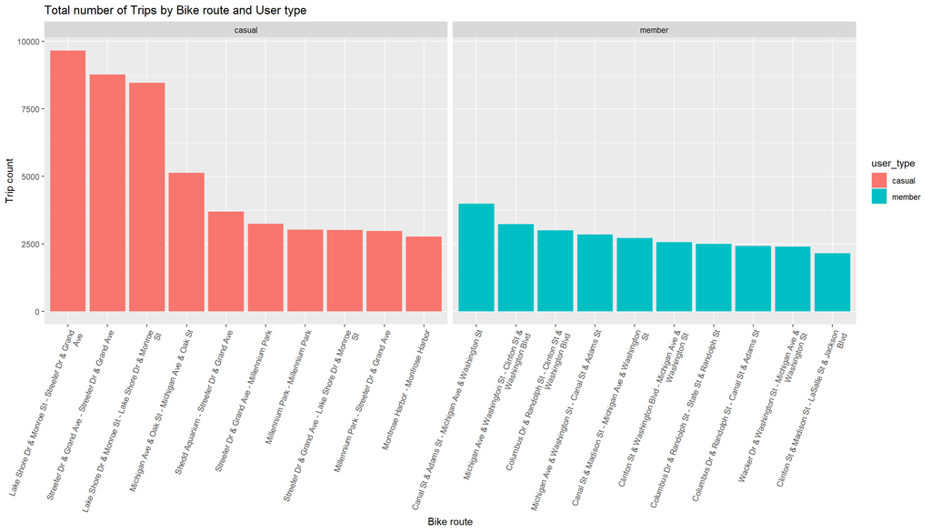

```r
# Total number of trips by Bike route and User type : Top 10 routes - Column Chart

ggplot(summary5_df, aes(x = reorder_within(str_wrap(bike_route, 50), -total_trip_count, user_type),
                        y = total_trip_count,
                        fill = user_type)) +
  geom_col(position = "identity") +
  labs(title = "Total number of Trips by Bike route and User type",
       x = "Bike route",
       y = "Trip count") +
  theme(axis.text.x = element_text(angle = 70, hjust = 1))+
  scale_x_reordered() +
  facet_wrap(~user_type, scales = "free_x")
```

- **Total trip count by route for Casual riders -> MAP**

```r
# Total trip count by route for Casual riders -> MAP

 ## Get top 10 routes for casual users
top_routes <- all_trips_19_20_10 %>%
  filter(user_type == "casual") %>%
  group_by(start_station_name, end_station_name) %>%
  summarise(total_trip_count = n(), .groups = "drop") %>%
  arrange(desc(total_trip_count)) %>%
  slice_head(n = 10)

## Extract start and end stations
start_stations <- top_routes %>%
  select(station_name = start_station_name)

end_stations <- top_routes %>%
  select(station_name = end_station_name)

## Combine and get unique station names
unique_stations <- bind_rows(start_stations, end_stations) %>%
  distinct(station_name)

## Extracted the coordinates of stations using geocode function, and then saved it in a csv file. Which then is being read now.
casual_routes_stations <- read.csv("casual_top_routes_stations_trips_geocoded.csv")


## Create the map
map_trip_count_casual_route <- leaflet(casual_routes_stations) %>%
  addProviderTiles(providers$CartoDB.Positron) %>%
  addCircleMarkers(
    ~longitude, ~latitude,
    radius = 6,
    color = "red",
    fillOpacity = 0.9,
    stroke = FALSE,
    popup = ~paste0(":</strong> ", station_name, "<br>"
    )
  ) %>%
  addControl(
    html = paste0(
      "<div style='text-align:left; padding:8px; font-size:12px; background:white; border-radius:8px;'>",
      "<strong>Trip frequency : Stations from Top 10 Routes (Casual Riders)</strong><br>",
      paste0(
        casual_routes_stations %>%
          mutate(label = paste0(" * ", station_name)) %>%
          pull(label),
        collapse = "<br>"
      ),
      "</div>"
    ),
    position = "topright"
  )

map_trip_count_casual_route
```

[interactive chart not shown]

- **Total trip count by route for Annual members -> MAP**

```r
# Total trip count by route for Annual members -> MAP

 ## Get top 10 routes for annual members
top_routes_1 <- all_trips_19_20_10 %>%
  filter(user_type == "member") %>%
  group_by(start_station_name, end_station_name) %>%
  summarise(total_trip_count = n(), .groups = "drop") %>%
  arrange(desc(total_trip_count)) %>%
  slice_head(n = 10)

## Extract start and end stations
start_stations_1 <- top_routes_1 %>%
  select(station_name = start_station_name)

end_stations_1 <- top_routes_1 %>%
  select(station_name = end_station_name)

## Combine and get unique station names
unique_stations_1 <- bind_rows(start_stations_1, end_stations_1) %>%
  distinct(station_name)
unique_stations_1
```

```
## # A tibble: 9 × 1
##   station_name
##   <chr>
## 1 Canal St & Adams St
## 2 Michigan Ave & Washington St
## 3 Columbus Dr & Randolph St
## 4 Canal St & Madison St
## 5 Clinton St & Washington Blvd
## 6 Wacker Dr & Washington St
## 7 Clinton St & Madison St
## 8 State St & Randolph St
## 9 LaSalle St & Jackson Blvd
```

```r
## Extracted the coordinates of stations using geocode function, and then saved it in a csv file. Which then is being read now.
member_routes_stations <- read.csv("member_top_routes_stations_trips_geocoded.csv")


## Create the map
map_trip_count_member_route <- leaflet(member_routes_stations) %>%
  addProviderTiles(providers$CartoDB.Positron) %>%
  addCircleMarkers(
    ~longitude, ~latitude,
    radius = 6,
    color = "blue",
    fillOpacity = 0.9,
    stroke = FALSE,
    popup = ~paste0(":</strong> ", station_name, "<br>"
    )
  ) %>%
  addControl(
    html = paste0(
      "<div style='text-align:left; padding:8px; font-size:12px; background:white; border-radius:8px;'>",
      "<strong>Trip frequency : Stations from Top 10 Routes (Annual members)</strong><br>",
      paste0(
        member_routes_stations %>%
          mutate(label = paste0(" * ", station_name)) %>%
          pull(label),
        collapse = "<br>"
      ),
      "</div>"
    ),
    position = "topright"
  )

map_trip_count_member_route
```

[interactive chart not shown]

**(7A)**

0. When Starting station and Ending station are same, then it means that the user went for a ride from the starting station, and after the ride, finished the ride at the same station
1. Casual riders : “Lake Shore Dr & Monroe St - Streeter Dr & Grand Ave” is the most busiest route for Casual riders. All stations of the Top 10 busy routes are located near the Lake side
2. Annual members : “Canal St & Adams St - Michigan Ave & Washington St” is the most busiest route for Annual members. All stations of the Top 10 busy routes are concentrated away from the Lake side.

*5) Total number of trips by Gender and User type (2019 - 2020 Q1) :*

```r
# Total number of trips by Gender and Usertype- Summary

summary6_df <- all_trips_19_20_10 %>%
  filter(is.na(gender) == FALSE) %>%
  group_by(gender, user_type) %>%
  summarize(
    total_trip_count = n(), .groups = "drop"
    ) %>%
  group_by(user_type)

# Summary long table view

head(summary6_df %>% pivot_wider(
    names_from = user_type,
    values_from = c(total_trip_count)))
```

```
## # A tibble: 2 × 3
##   gender casual  member
##   <fct>   <int>   <int>
## 1 Female 131263  726349
## 2 Male   212493 2186707
```

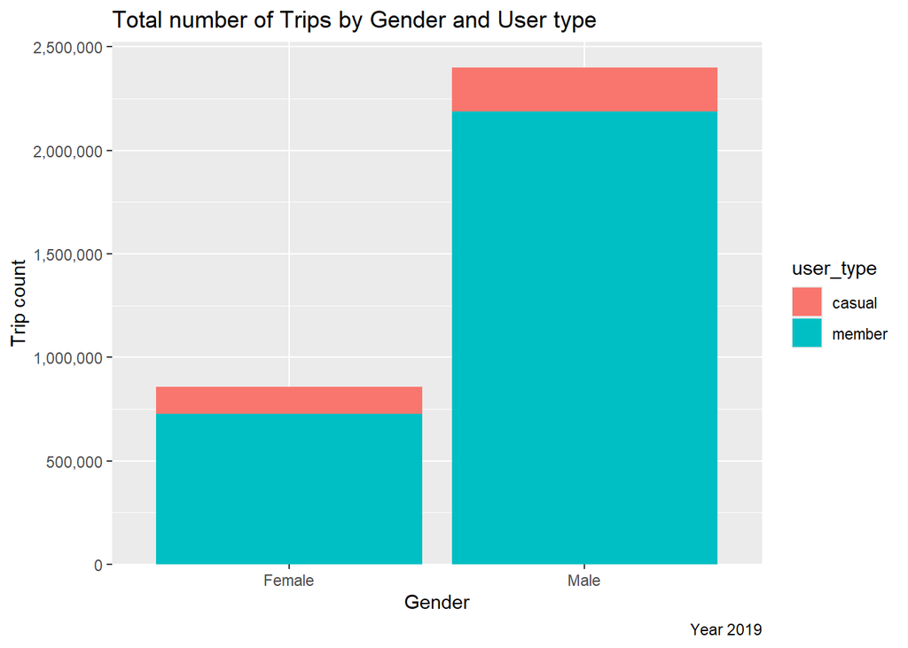

```r
# Total number of trips by Gender and User type  - Column Chart

ggplot(summary6_df, aes(x = gender,
                        y = total_trip_count,
                        fill = user_type)) +
  geom_col(position = "stack") +
  labs(title = "Total number of Trips by Gender and User type",
       x = "Gender",
       y = "Trip count",
       caption = "Year 2019") +
  scale_y_continuous(limits = c(0, 2500000),
                     labels = scales::comma,
                     expand = expansion(mult = c(0, 0.01)))
```

**(8A)**

1. There are total 0.85 Million Trip counts for Female riders and 2.4 Million of that for Male riders in the Year 2019
2. Casual riders : Among casual riders, 38% of trips were made by females, while 62% were made by males.
3. Annual members : Among annual members, 25% of trips were made by females, whereas 75% were made by males.
4. Female riders :Among female riders, only 15% of total trips were made by casual riders, while a dominant 85% were taken by annual members.
5. Male riders : Among male riders, only 8.8% of total trips were made by casual riders, while a dominant 91.2% were taken by annual members.

*6) Total number of trips by Age and User type (2019 - 2020 Q1) :*

```r
# Total number of trips by Age and User type - Summary

summary7_df <- all_trips_19_20_10 %>%
  filter(is.na(rider_age) == FALSE) %>%
  group_by(rider_age, user_type) %>%
  summarize(
    total_trip_count = n(), .groups = "drop"
    ) %>%
  group_by(user_type)

# Summary long table view

glimpse(summary7_df %>% pivot_wider(
    names_from = user_type,
    values_from = c(total_trip_count)) %>%
      arrange(desc(rider_age)))
```

```
## Rows: 74
## Columns: 3
## $ rider_age <dbl> 90, 89, 88, 86, 85, 84, 83, 82, 81, 80, 79, 78, 77, 76, 75, …
## $ casual    <int> NA, NA, 1, NA, NA, 3, 1, 4, NA, 2, 17, 4, 5, 15, 17, 9, 20, …
## $ member    <int> 5, 35, 11, 20, 19, NA, NA, NA, 12, 88, 226, 119, 236, 93, 37…
```

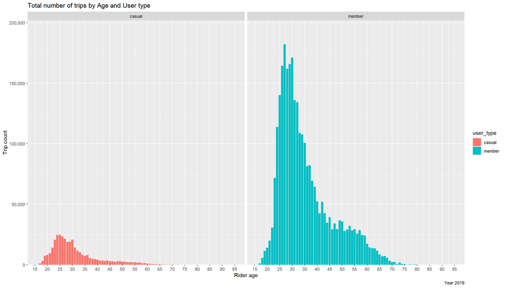

```r
# Total number of trips by Age and User type  - Column Chart

ggplot(summary7_df, aes(x = rider_age,
                        y = total_trip_count,
                        fill = user_type)) +
  geom_col(position = "identity") +
  labs(title = "Total number of trips by Age and User type",
       x = "Rider age",
       y = "Trip count",
       caption = "Year 2019") +
  scale_y_continuous(limits = c(0, 200000),
                     labels = scales::comma,
                     expand = expansion(mult = c(0, 0.01))) +
  scale_x_continuous(limits = c(16, 95),
                     breaks = seq(15, 95, by = 5)) +
  facet_wrap(~user_type)
```

```r
# Rider age having the highest trip count.

summary7_df %>%
  group_by(user_type) %>%
  filter(total_trip_count == max(total_trip_count)) %>%
  select(user_type, rider_age, total_trip_count)
```

```
## # A tibble: 2 × 3
## # Groups:   user_type [2]
##   user_type rider_age total_trip_count
##   <fct>         <dbl>            <int>
## 1 casual           25            24778
## 2 member           27           182150
```

```r
# Average trip count for a rider of any age by User type :

head(summary7_df %>%
       group_by(user_type) %>%
       summarise(average_trip_count = mean(total_trip_count)) %>%
     select(user_type, average_trip_count))
```

```
## # A tibble: 2 × 2
##   user_type average_trip_count
##   <fct>                  <dbl>
## 1 casual                 5040.
## 2 member                41260.
```

**(9A)**

1. Casual riders : The Age range of 18 to 36 is where there are more than 80% of the Total trip counts in the Year 2019. Age of 25 is the rider age having the highest trip count ie; approx. 25k. The Average trip count of Casuals of any age is about just 5,000
2. Annual members : The Age range of 22 to 60 is where there are more than 80% of the Total trip counts in the Year 2019. Age of 27 is the rider age having the highest trip count ie; approx. 180k. The Average trip count of an annual member any age is about 41,000.